# More Guns, Less Crime?

Viola Group

7/30/2018

```r
knitr::opts_chunk$set(
    echo = TRUE,
    message = FALSE,
    warning = FALSE
)
options(scipen =10, show.signif.stars = FALSE)
```

# Guns dataset from the “AER”" package.

- **Dataset is a balanced panel of data on 50 US states, plus the District of Columbia (for a total of 51 states), by year for 1977–1999, and contains 1,173 observations on 13 variables. The variables are:**
  - *state:* factor indicating state.
  - *year:* factor indicating year.
  - *violent:* violent crime rate (incidents per 100,000 members of the population).
  - *murder:* murder rate (incidents per 100,000).
  - *robbery:* robbery rate (incidents per 100,000).
  - *prisoners:* incarceration rate in the state in the previous year (sentenced prisoners per 100,000 residents;value for the previous year).
  - *afam:* percent of state population that is African-American, ages 10 to 64.
  - *cauc:* percent of state population that is Caucasian, ages 10 to 64.
  - *male:* percent of state population that is male, ages 10 to 29.
  - *population:* state population, in millions of people.
  - *income:* real per capita personal income in the state (US dollars).
  - *density:* population per square mile of land area, divided by 1,000.
  - *law:* factor. Does the state have a shall carry law in effect in that year?

## Objective: Identify if having more guns, reduces violence.

**Install and load the AER Package**

```r
#install.packages("AER", repos = "http://cran.us.r-project.org", type = "source")
library("AER")
```

**Load the *Guns* dataset from the AER Package**

```r
data("Guns")
```

**Examine the structure and summary of the *Guns* dataset**

```r
str(Guns)  #print the structure
```

```
## 'data.frame':    1173 obs. of  13 variables:
##  $ year      : Factor w/ 23 levels "1977","1978",..: 1 2 3 4 5 6 7 8 9 10 ...
##  $ violent   : num  414 419 413 448 470 ...
##  $ murder    : num  14.2 13.3 13.2 13.2 11.9 10.6 9.2 9.4 9.8 10.1 ...
##  $ robbery   : num  96.8 99.1 109.5 132.1 126.5 ...
##  $ prisoners : int  83 94 144 141 149 183 215 243 256 267 ...
##  $ afam      : num  8.38 8.35 8.33 8.41 8.48 ...
##  $ cauc      : num  55.1 55.1 55.1 54.9 54.9 ...
##  $ male      : num  18.2 18 17.8 17.7 17.7 ...
##  $ population: num  3.78 3.83 3.87 3.9 3.92 ...
##  $ income    : num  9563 9932 9877 9541 9548 ...
##  $ density   : num  0.0746 0.0756 0.0762 0.0768 0.0772 ...
##  $ state     : Factor w/ 51 levels "Alabama","Alaska",..: 1 1 1 1 1 1 1 1 1 1 ...
##  $ law       : Factor w/ 2 levels "no","yes": 1 1 1 1 1 1 1 1 1 1 ...
```

```r
summary(Guns)  #Identify the missing values
```

```
##       year        violent           murder          robbery
##  1977   : 51   Min.   :  47.0   Min.   : 0.200   Min.   :   6.4
##  1978   : 51   1st Qu.: 283.1   1st Qu.: 3.700   1st Qu.:  71.1
##  1979   : 51   Median : 443.0   Median : 6.400   Median : 124.1
##  1980   : 51   Mean   : 503.1   Mean   : 7.665   Mean   : 161.8
##  1981   : 51   3rd Qu.: 650.9   3rd Qu.: 9.800   3rd Qu.: 192.7
##  1982   : 51   Max.   :2921.8   Max.   :80.600   Max.   :1635.1
##  (Other):867
##    prisoners           afam              cauc            male
##  Min.   :  19.0   Min.   : 0.2482   Min.   :21.78   Min.   :12.21
##  1st Qu.: 114.0   1st Qu.: 2.2022   1st Qu.:59.94   1st Qu.:14.65
##  Median : 187.0   Median : 4.0262   Median :65.06   Median :15.90
##  Mean   : 226.6   Mean   : 5.3362   Mean   :62.95   Mean   :16.08
##  3rd Qu.: 291.0   3rd Qu.: 6.8507   3rd Qu.:69.20   3rd Qu.:17.53
##  Max.   :1913.0   Max.   :26.9796   Max.   :76.53   Max.   :22.35
##
##    population          income         density                 state
##  Min.   : 0.4027   Min.   : 8555   Min.   : 0.000707   Alabama   :  23
##  1st Qu.: 1.1877   1st Qu.:11935   1st Qu.: 0.031911   Alaska    :  23
##  Median : 3.2713   Median :13402   Median : 0.081569   Arizona   :  23
##  Mean   : 4.8163   Mean   :13725   Mean   : 0.352038   Arkansas  :  23
##  3rd Qu.: 5.6856   3rd Qu.:15271   3rd Qu.: 0.177718   California:  23
##  Max.   :33.1451   Max.   :23647   Max.   :11.102120   Colorado  :  23
##                                                        (Other)   :1035
##   law
##  no :888
##  yes:285
##
##
##
##
##
```

**Explanation:** Based on the data summary, none of the variables appear to have missing values.

**Identify the column number associated with each variable**

```r
names(Guns)
```

```
##  [1] "year"       "violent"    "murder"     "robbery"    "prisoners"
##  [6] "afam"       "cauc"       "male"       "population" "income"
## [11] "density"    "state"      "law"
```

## Explore the distribution of the violent crime rate

```r
x <- sort(Guns$violent)
m <- mean(Guns$violent)
std <- sd(Guns$violent)
```

**Plots of the violent crime rate**

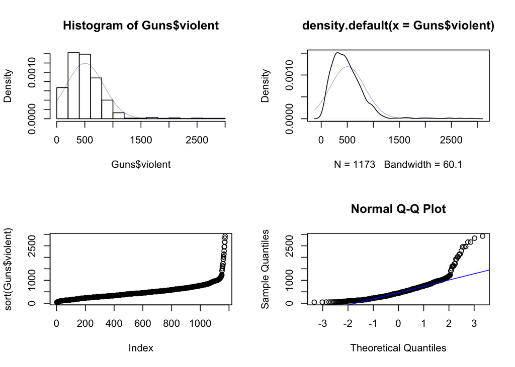

```r
old <- par(mfrow=c(2,2))
#histogram
hist(Guns$violent, freq=FALSE)
curve(dnorm(x, mean=m, sd=std), col="darkblue", lwd=0.25,add = TRUE)
#density plot
plot(density(Guns$violent))
curve(dnorm(x, mean=m, sd=std), col="darkblue", lwd=0.25,add = TRUE)
#sortplot
plot(sort(Guns$violent))
#QQ-Plot
qqnorm(Guns$violent)
qqline(Guns$violent, col="blue")
```

```r
par(old)
```

**Explanation** After examining the above plots, the *violent* variable does not appear to be normally distributed. In the histogram, the distribution of the *violent* variable deviates from the normal distribution. Aditionally, the actual values of the *violent* varibale do not adhere to the blue QQ-line on the the QQ-Plot. The *violent* variable is skewed to the right (positively skewed) and the mean (503.074) > median (443). On the Sort Plot there appears to be a few clusters on the right side of the plot, where the violent crime rate is high. Based on the fact that the *violent* variable is skewed to the right I would consider the use a “log()” transformation on this variable, The “log()” transformation could reduce the skewness, which in turn could make it easier to interpret whether or not a relationship exist between variables that might not have otherwise been obvious.

## Examine the Scatterplot Matrix of the dataset

**Plot the scatterplot matrix**

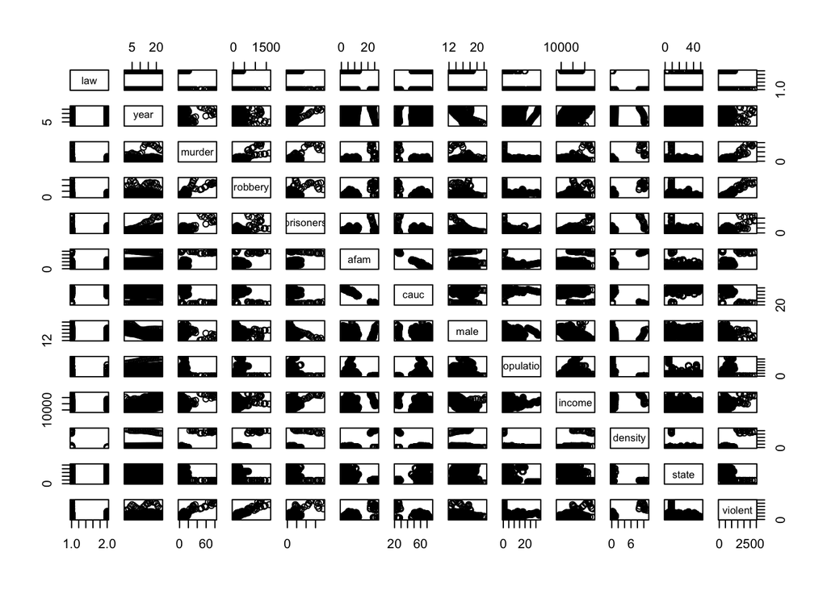

```r
pairs(~ law + year + murder + robbery + prisoners + afam + cauc + male + population + income + density + state + violent, data=Guns)
```

**Explanation:** There appears to be a positive relationship between the dependent variable *violent* and the independent variables *murder*, *robbery*, *prisoner*, *afam*, and *density* as well as a negative relationship between *violent* and *cauc*. However its difficult to examine the variables using the pairs function, therefore lets try the ggpairs function from GGally package.

**Before you can use the ggpairs function, create a duplicate dataset called Guns1 and convert the factor variables *state* and *year* into numerics because factors with levels greater than 15, will cause a processing error.**

```r
Guns1 <-Guns
Guns1$state <- as.numeric(Guns1$state)
Guns1$year <- as.numeric(Guns1$year)
```

**Confirm the variables were converted**

```r
str(Guns1)
```

```
## 'data.frame':    1173 obs. of  13 variables:
##  $ year      : num  1 2 3 4 5 6 7 8 9 10 ...
##  $ violent   : num  414 419 413 448 470 ...
##  $ murder    : num  14.2 13.3 13.2 13.2 11.9 10.6 9.2 9.4 9.8 10.1 ...
##  $ robbery   : num  96.8 99.1 109.5 132.1 126.5 ...
##  $ prisoners : int  83 94 144 141 149 183 215 243 256 267 ...
##  $ afam      : num  8.38 8.35 8.33 8.41 8.48 ...
##  $ cauc      : num  55.1 55.1 55.1 54.9 54.9 ...
##  $ male      : num  18.2 18 17.8 17.7 17.7 ...
##  $ population: num  3.78 3.83 3.87 3.9 3.92 ...
##  $ income    : num  9563 9932 9877 9541 9548 ...
##  $ density   : num  0.0746 0.0756 0.0762 0.0768 0.0772 ...
##  $ state     : num  1 1 1 1 1 1 1 1 1 1 ...
##  $ law       : Factor w/ 2 levels "no","yes": 1 1 1 1 1 1 1 1 1 1 ...
```

```r
summary(Guns1)
```

```
##       year       violent           murder          robbery
##  Min.   : 1   Min.   :  47.0   Min.   : 0.200   Min.   :   6.4
##  1st Qu.: 6   1st Qu.: 283.1   1st Qu.: 3.700   1st Qu.:  71.1
##  Median :12   Median : 443.0   Median : 6.400   Median : 124.1
##  Mean   :12   Mean   : 503.1   Mean   : 7.665   Mean   : 161.8
##  3rd Qu.:18   3rd Qu.: 650.9   3rd Qu.: 9.800   3rd Qu.: 192.7
##  Max.   :23   Max.   :2921.8   Max.   :80.600   Max.   :1635.1
##    prisoners           afam              cauc            male
##  Min.   :  19.0   Min.   : 0.2482   Min.   :21.78   Min.   :12.21
##  1st Qu.: 114.0   1st Qu.: 2.2022   1st Qu.:59.94   1st Qu.:14.65
##  Median : 187.0   Median : 4.0262   Median :65.06   Median :15.90
##  Mean   : 226.6   Mean   : 5.3362   Mean   :62.95   Mean   :16.08
##  3rd Qu.: 291.0   3rd Qu.: 6.8507   3rd Qu.:69.20   3rd Qu.:17.53
##  Max.   :1913.0   Max.   :26.9796   Max.   :76.53   Max.   :22.35
##    population          income         density              state
##  Min.   : 0.4027   Min.   : 8555   Min.   : 0.000707   Min.   : 1
##  1st Qu.: 1.1877   1st Qu.:11935   1st Qu.: 0.031911   1st Qu.:13
##  Median : 3.2713   Median :13402   Median : 0.081569   Median :26
##  Mean   : 4.8163   Mean   :13725   Mean   : 0.352038   Mean   :26
##  3rd Qu.: 5.6856   3rd Qu.:15271   3rd Qu.: 0.177718   3rd Qu.:39
##  Max.   :33.1451   Max.   :23647   Max.   :11.102120   Max.   :51
##   law
##  no :888
##  yes:285
##
##
##
##
```

**Use fancy scatterplot matrix, but use Guns1 to avoid a processing error.**

```r
library("GGally") #load GGally package
```

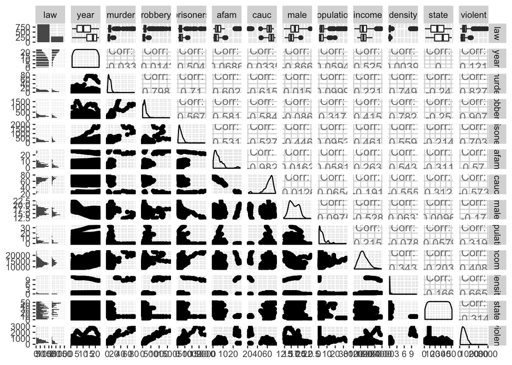

```r
ggpairs(Guns1, columns = c(13, 1, 3:12, 2))
```

**Add colors to the scatterplot matrix to see how the factor variable *law* effects other variables.**

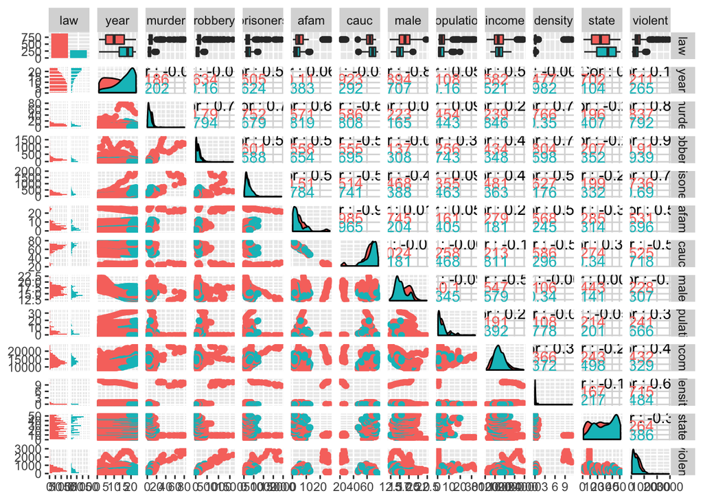

```r
ggpairs(Guns1, columns = c(13, 1, 3:12, 2), mapping = aes(color = law))
```

**Explanation** Based on the ggpairs scatterplot, the variables *murder* and *robbery* have the strongest positive linear relationship with the violent crime rate, with a correlation value of 0.827 and 0.907 respectively. Considering these variables are components of the violent crime rate, we expected there to be high correlation values. However with that being said, these variables are more of a subcategory of violent crimes and therefore aren’t good predictors for a linear model. Other variables that showed a high correlation value were prisoners (0.703), density (0.665), afam (0.57), cauc(-0.573), and income (0.408). The law variable was also a good indicator because the box plot showed that on average states that have a shall carry law in effect have a lower violent crime rate as well as as a lower murder and robbery rate.

## Examination of Simple Regression models

**Model (m1): Examine the relationship between the violent crime rate and having a shall carry law in effect**

```r
m1 <- lm(violent~ law, data = Guns)
summary(m1)
```

```
##
## Call:
## lm(formula = violent ~ law, data = Guns)
##
## Residuals:
##     Min      1Q  Median      3Q     Max
## -495.24 -228.84  -63.64  134.06 2379.56
##
## Coefficients:
##             Estimate Std. Error t value          Pr(>|t|)
## (Intercept)   542.24      10.98  49.386           < 2e-16
## lawyes       -161.19      22.27  -7.236 0.000000000000832
##
## Residual standard error: 327.2 on 1171 degrees of freedom
## Multiple R-squared:  0.0428, Adjusted R-squared:  0.04199
## F-statistic: 52.36 on 1 and 1171 DF,  p-value: 0.0000000000008319
```

**Explanation:** The summary of model m1 identifies that States that have a shall carry law in effect will have an average violent crime rate of 381.05 (542.24 - 161.19). States that don’t have a shall carry law in effect will have an average violent crime rate of 542.24.

**Model (m2): Examine the relationship between the violent crime rate and the incarceration rate in the state in the previous year.**

```r
m2 <- lm(violent~ prisoners, data = Guns)
summary(m2)
```

```
##
## Call:
## lm(formula = violent ~ prisoners, data = Guns)
##
## Residuals:
##      Min       1Q   Median       3Q      Max
## -1089.67  -146.50   -36.36   116.03  1509.88
##
## Coefficients:
##              Estimate Std. Error t value Pr(>|t|)
## (Intercept) 205.57155   11.21480   18.33   <2e-16
## prisoners     1.31302    0.03885   33.79   <2e-16
##
## Residual standard error: 237.9 on 1171 degrees of freedom
## Multiple R-squared:  0.4937, Adjusted R-squared:  0.4933
## F-statistic:  1142 on 1 and 1171 DF,  p-value: < 2.2e-16
```

**Model (m3): Examine the relationship between the violent crime rate and the % of state population that is male, ages 10 to 29.**

```r
m3 <- lm(violent~ male, data = Guns)
summary(m3)
```

```
##
## Call:
## lm(formula = violent ~ male, data = Guns)
##
## Residuals:
##     Min      1Q  Median      3Q     Max
## -489.60 -212.18  -51.65  149.53 2352.46
##
## Coefficients:
##             Estimate Std. Error t value      Pr(>|t|)
## (Intercept) 1029.558     89.892  11.453       < 2e-16
## male         -32.739      5.558  -5.891 0.00000000502
##
## Residual standard error: 329.6 on 1171 degrees of freedom
## Multiple R-squared:  0.02878,    Adjusted R-squared:  0.02795
## F-statistic:  34.7 on 1 and 1171 DF,  p-value: 0.000000005021
```

**Explanation:** The summary of model m3 identifies that a 1% increase in the state population that is male, ages 10 to 29, will decrease the average violent crime rate by 32.739.

**Model (m4): Examine the relationship between the violent crime rate and the real per capita personal income in the state (US Dollars).**

```r
m4 <- lm(violent~ income, data = Guns)
summary(m4)
```

```
##
## Call:
## lm(formula = violent ~ income, data = Guns)
##
## Residuals:
##     Min      1Q  Median      3Q     Max
## -687.18 -204.21  -42.73  146.65 1986.69
##
## Coefficients:
##                Estimate  Std. Error t value   Pr(>|t|)
## (Intercept) -229.657476   48.738842  -4.712 0.00000275
## income         0.053387    0.003491  15.292    < 2e-16
##
## Residual standard error: 305.3 on 1171 degrees of freedom
## Multiple R-squared:  0.1665, Adjusted R-squared:  0.1657
## F-statistic: 233.8 on 1 and 1171 DF,  p-value: < 2.2e-16
```

**Explanation:** The summary of model m4 identifies that as the real per capita personal income in the state goes up by $1, the average violent crime rate will increase by 0.053387.**

## Examination of multipe Regression models

**First examine the model with all variables as predictors except the variables *murder* and *robbery* because they are components of the violent crime rate**

**Use the dataset “Guns1”, which convert the factor variables *state* and *year* into numerics. Only factor variable to remain is *law*.**

```r
m5 <- lm(violent~law + prisoners+ density + income + population + afam + cauc + male + state + year, data = Guns1)
summary(m5)
```

```
##
## Call:
## lm(formula = violent ~ law + prisoners + density + income + population +
##     afam + cauc + male + state + year, data = Guns1)
##
## Residuals:
##      Min       1Q   Median       3Q      Max
## -1113.81  -110.17   -28.29   104.38   649.44
##
## Coefficients:
##               Estimate Std. Error t value        Pr(>|t|)
## (Intercept)  28.701244 218.862755   0.131         0.89569
## lawyes      -58.044058  13.607469  -4.266 0.0000215560812
## prisoners     0.910460   0.046231  19.694         < 2e-16
## density      83.991132   5.691054  14.758         < 2e-16
## income       -0.000265   0.003160  -0.084         0.93319
## population   18.023968   1.025594  17.574         < 2e-16
## afam         27.050733   6.925226   3.906 0.0000991972748
## cauc         10.799793   3.465812   3.116         0.00188
## male        -27.686490   6.776743  -4.086 0.0000469964918
## state        -2.219606   0.367097  -6.046 0.0000000019936
## year        -12.646927   1.924193  -6.573 0.0000000000745
##
## Residual standard error: 170.3 on 1162 degrees of freedom
## Multiple R-squared:  0.7428, Adjusted R-squared:  0.7406
## F-statistic: 335.6 on 10 and 1162 DF,  p-value: < 2.2e-16
```

**Examine the coefficient estimates with a particular focus on *lawyes*.**

```r
coef(m5)
```

```
##    (Intercept)         lawyes      prisoners        density         income
##  28.7012435729 -58.0440578681   0.9104601011  83.9911323217  -0.0002649686
##     population           afam           cauc           male          state
##  18.0239677138  27.0507329512  10.7997933019 -27.6864902433  -2.2196055166
##           year
## -12.6469265649
```

**Explanation:** Based on this model; states that have a shall carry law in effect are more likely to have a lower violent crime rate. Holding all other variables equal, a state without a shall carry law on average will have 58.04407 more incidents per 100,000 members of the population.

### How well does the Model Fit?

**Lets look at the Model Fit (Coefficient of Determination)**

```r
summary(m5)$r.square
```

```
## [1] 0.7428019
```

**Explanation:** The model explains approximately 74.28% of the variability of the response data around its mean.

**Fitted Plot**

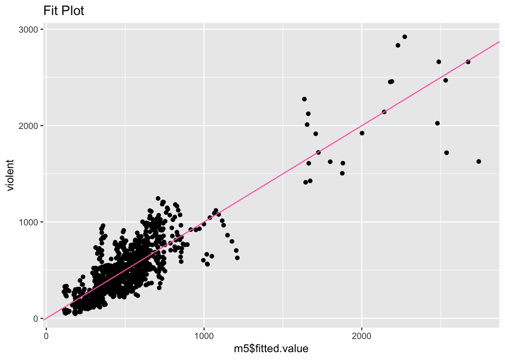

```r
library(ggplot2) #load ggplot 2 package
qplot(m5$fitted.value, violent, data=Guns1) +
geom_abline(intercept = 0, slope = 1, color="hot pink") +
ggtitle("Fit Plot")
```

**Explanation:** The plot shows that the actual values fluctuate fairly significantly from the fitted values(pink reference line).

**Residuals vs. Fitted**

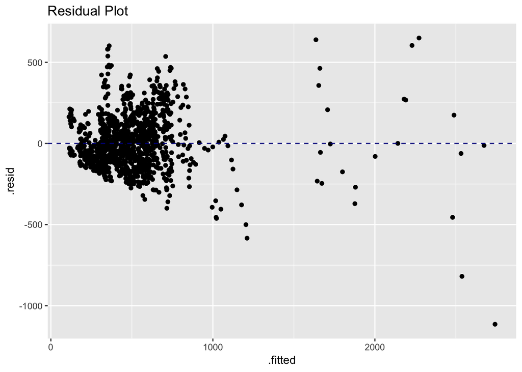

```r
ggplot(m5, aes(.fitted, .resid)) +
geom_point() +
geom_hline(yintercept=0, color="dark blue", linetype="dashed") +
ggtitle("Residual Plot")
```

**Explanation:** The Residual plot shows that a majority of the observed values fall within +/-500 of the fitted values. However this could be considered a substantialy deviation from the fitted values. Therefore lets examine if a log transformation would be useful.

**Create another model using log(violent)**

```r
m6 <- lm(log(violent)~law + prisoners+ density + income + population + afam + cauc + male + state + year, data = Guns1)
summary(m6)
```

```
##
## Call:
## lm(formula = log(violent) ~ law + prisoners + density + income +
##     population + afam + cauc + male + state + year, data = Guns1)
##
## Residuals:
##      Min       1Q   Median       3Q      Max
## -1.87266 -0.26038  0.03761  0.29765  1.04136
##
## Coefficients:
##                 Estimate   Std. Error t value        Pr(>|t|)
## (Intercept)  3.408349112  0.531667972   6.411 0.0000000002102
## lawyes      -0.291034574  0.033055673  -8.804         < 2e-16
## prisoners    0.001799160  0.000112306  16.020         < 2e-16
## density      0.006336184  0.013824880   0.458           0.647
## income      -0.000003897  0.000007677  -0.508           0.612
## population   0.041848478  0.002491404  16.797         < 2e-16
## afam         0.115330271  0.016822966   6.856 0.0000000000115
## cauc         0.049401206  0.008419256   5.868 0.0000000057588
## male        -0.069758510  0.016462268  -4.237 0.0000243937214
## state       -0.005959937  0.000891762  -6.683 0.0000000000362
## year        -0.026378922  0.004674307  -5.643 0.0000000209365
##
## Residual standard error: 0.4136 on 1162 degrees of freedom
## Multiple R-squared:  0.5932, Adjusted R-squared:  0.5897
## F-statistic: 169.5 on 10 and 1162 DF,  p-value: < 2.2e-16
```

### How well does the log transformed Model Fit?

**Lets look at the log transformed Model Fit (Coefficient of Determination)**

```r
summary(m6)$r.square
```

```
## [1] 0.5932152
```

**Explanation:** The model explains approximately 59.32% of the variability of the response data around its mean.

**Log Transformation Fitted Plot**

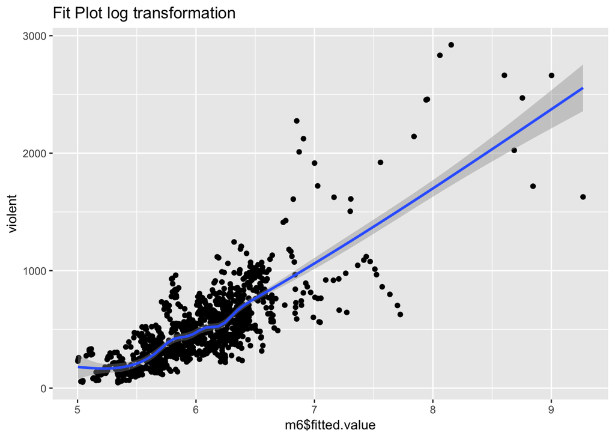

```r
qplot(m6$fitted.value, violent, data=Guns1) +geom_smooth() +ggtitle("Fit Plot log transformation")
```

**Explanation:** The plot shows that the actual values fluctuate fairly significantly from the fitted values(blue reference line).

**Log Transformation Residuals vs. Fitted**

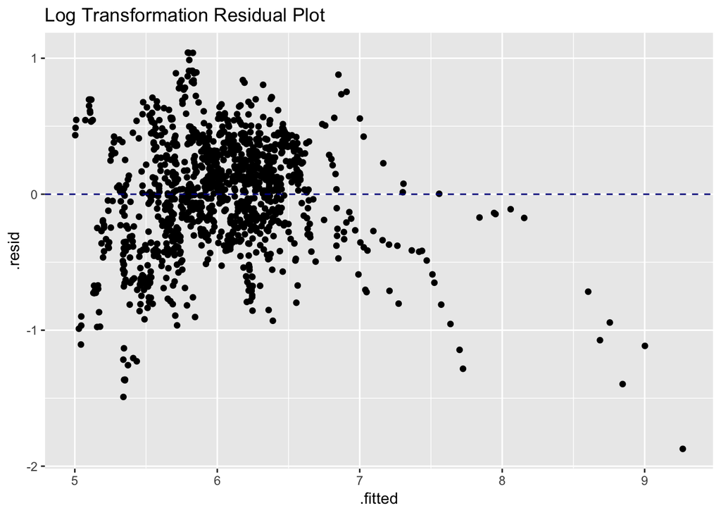

```r
ggplot(m6, aes(.fitted, .resid)) +
geom_point() +
geom_hline(yintercept=0, color="dark blue", linetype="dashed") +
ggtitle("Log Transformation Residual Plot")
```

**some values fall outside of the observed values fall outside of the range and therefore its in our best interest to examine smaller models that could dimish the variability further.**

## Hypothesis Testing

### Comparison 1

**Create a linear model with all of the same variables except the *year* variable as predictors of the log transformation of the violent crime rate.**

```r
m7 <- lm(log(violent)~law + prisoners+ density + income + population + afam + cauc + male + state, data = Guns1)
summary(m7)
```

```
##
## Call:
## lm(formula = log(violent) ~ law + prisoners + density + income +
##     population + afam + cauc + male + state, data = Guns1)
##
## Residuals:
##      Min       1Q   Median       3Q      Max
## -1.65588 -0.26486  0.03931  0.29713  0.97863
##
## Coefficients:
##                 Estimate   Std. Error t value         Pr(>|t|)
## (Intercept)  2.952423211  0.532417542   5.545 0.00000003629454
## lawyes      -0.344439918  0.032089401 -10.734          < 2e-16
## prisoners    0.001558557  0.000105268  14.806          < 2e-16
## density      0.035838571  0.012966968   2.764           0.0058
## income      -0.000008208  0.000007739  -1.061           0.2891
## population   0.043393443  0.002508944  17.296          < 2e-16
## afam         0.088519530  0.016350838   5.414 0.00000007491872
## cauc         0.037451694  0.008256001   4.536 0.00000631812373
## male         0.001964568  0.010601215   0.185           0.8530
## state       -0.006342402  0.000900898  -7.040 0.00000000000328
##
## Residual standard error: 0.419 on 1163 degrees of freedom
## Multiple R-squared:  0.5821, Adjusted R-squared:  0.5788
## F-statistic:   180 on 9 and 1163 DF,  p-value: < 2.2e-16
```

- **Compare two models:**
  - *Model 7: log(violent) ~ law + prisoners + density + income + population + afam + cauc + male + state*
  - *Model 6: log(violent)~ law + prisoners + density + income + population + afam + cauc + male + state + year*

**Run anova function**

```r
tab2 <- anova(m7, m6)
tab2
```

```
## Analysis of Variance Table
##
## Model 1: log(violent) ~ law + prisoners + density + income + population +
##     afam + cauc + male + state
## Model 2: log(violent) ~ law + prisoners + density + income + population +
##     afam + cauc + male + state + year
##   Res.Df    RSS Df Sum of Sq      F        Pr(>F)
## 1   1163 204.22
## 2   1162 198.77  1    5.4478 31.848 0.00000002094
```

**Explanation:** The F-ratio 31.848 is large enough and the p-value 0.00000002094, is smaller than $\alpha$ = .05; therefore the bigger Model (m6) is better. Based on this information you can conclude that the *year* variable affect the violent crime rate.

### Comparison 2

**Create a linear model with all of the same variables except the *state* variable as predictors of the log transformation of the violent crime rate.**

```r
m8 <- lm(log(violent)~law + prisoners+ density + income + population + afam + cauc + male + year, data = Guns1)
summary(m8)
```

```
##
## Call:
## lm(formula = log(violent) ~ law + prisoners + density + income +
##     population + afam + cauc + male + year, data = Guns1)
##
## Residuals:
##      Min       1Q   Median       3Q      Max
## -1.95488 -0.26980  0.05048  0.30652  1.02708
##
## Coefficients:
##                 Estimate   Std. Error t value       Pr(>|t|)
## (Intercept)  3.476772723  0.541456785   6.421 0.000000000197
## lawyes      -0.308600914  0.033563912  -9.194        < 2e-16
## prisoners    0.001871337  0.000113865  16.435        < 2e-16
## density     -0.004867769  0.013978114  -0.348          0.728
## income       0.000005285  0.000007693   0.687          0.492
## population   0.041070754  0.002534976  16.202        < 2e-16
## afam         0.110580314  0.017120581   6.459 0.000000000155
## cauc         0.044636393  0.008545054   5.224 0.000000207732
## male        -0.069761434  0.016768472  -4.160 0.000034125655
## year        -0.028753100  0.004747481  -6.056 0.000000001875
##
## Residual standard error: 0.4213 on 1163 degrees of freedom
## Multiple R-squared:  0.5776, Adjusted R-squared:  0.5743
## F-statistic: 176.7 on 9 and 1163 DF,  p-value: < 2.2e-16
```

- **Compare two models:**
  - *Model 8: log(violent) ~ law + prisoners + density + income + population + afam + cauc + male + year*
  - *Model 6: log(violent)~ law + prisoners + density + income + population + afam + cauc + male + state + year*

**Run anova function**

```r
tab3 <- anova(m8, m6)
tab3
```

```
## Analysis of Variance Table
##
## Model 1: log(violent) ~ law + prisoners + density + income + population +
##     afam + cauc + male + year
## Model 2: log(violent) ~ law + prisoners + density + income + population +
##     afam + cauc + male + state + year
##   Res.Df    RSS Df Sum of Sq      F           Pr(>F)
## 1   1163 206.41
## 2   1162 198.77  1    7.6406 44.667 0.00000000003617
```

**Explanation:** The F-ratio 44.667 is large enough and the p-value 0.00000000003617, is smaller than $\alpha$ = .05; therefore the bigger Model (m6) is better. Based on this information you can conclude that the *state* variable affect the violent crime rate.

### Comparison 3

**Create a linear model with all of the same variables except the *male* variable as predictors of the log transformation of the violent crime rate.**

```r
m9 <- lm(log(violent)~law + prisoners+ density + income + population + afam + cauc + state + year, data = Guns1)
summary(m9)
```

```
##
## Call:
## lm(formula = log(violent) ~ law + prisoners + density + income +
##     population + afam + cauc + state + year, data = Guns1)
##
## Residuals:
##      Min       1Q   Median       3Q      Max
## -1.83708 -0.26837  0.04119  0.29198  1.05331
##
## Coefficients:
##                 Estimate   Std. Error t value        Pr(>|t|)
## (Intercept)  3.084396658  0.529964512   5.820 0.0000000076024
## lawyes      -0.296647283  0.033269032  -8.917         < 2e-16
## prisoners    0.001774904  0.000112975  15.711         < 2e-16
## density      0.013040055  0.013833819   0.943        0.346070
## income       0.000005300  0.000007417   0.715        0.475029
## population   0.042109735  0.002508732  16.785         < 2e-16
## afam         0.082615533  0.015055429   5.487 0.0000000500239
## cauc         0.034630386  0.007719435   4.486 0.0000079716918
## state       -0.005960037  0.000898239  -6.635 0.0000000000495
## year        -0.011087277  0.002992552  -3.705        0.000221
##
## Residual standard error: 0.4166 on 1163 degrees of freedom
## Multiple R-squared:  0.5869, Adjusted R-squared:  0.5837
## F-statistic: 183.6 on 9 and 1163 DF,  p-value: < 2.2e-16
```

- **Compare two models:**
  - *Model 9: log(violent) ~ law + prisoners + density + income + population + afam + cauc + state + year*
  - *Model 6: log(violent)~ law + prisoners + density + income + population + afam + cauc + male + state + year*

**Run anova function**

```r
tab4 <- anova(m9, m6)
tab4
```

```
## Analysis of Variance Table
##
## Model 1: log(violent) ~ law + prisoners + density + income + population +
##     afam + cauc + state + year
## Model 2: log(violent) ~ law + prisoners + density + income + population +
##     afam + cauc + male + state + year
##   Res.Df    RSS Df Sum of Sq      F     Pr(>F)
## 1   1163 201.84
## 2   1162 198.77  1    3.0715 17.956 0.00002439
```

**Explanation:** The F-ratio 17.956 is large enough and the p-value 0.00002439, is smaller than $\alpha$ = .05; therefore the bigger Model (m6) is better. Based on this information you can conclude that the *male* variable affect the violent crime rate.

### Comparison 4

**Create a linear model with all of the same variables except the *density* variable as predictors of the log transformation of the violent crime rate.**

```r
m10 <- lm(log(violent)~law + prisoners + income + population + afam + cauc + male+ state + year, data = Guns1)
summary(m10)
```

```
##
## Call:
## lm(formula = log(violent) ~ law + prisoners + income + population +
##     afam + cauc + male + state + year, data = Guns1)
##
## Residuals:
##      Min       1Q   Median       3Q      Max
## -1.87764 -0.25876  0.03794  0.29655  1.04468
##
## Coefficients:
##                 Estimate   Std. Error t value        Pr(>|t|)
## (Intercept)  3.458610704  0.520058162   6.650 0.0000000000449
## lawyes      -0.289214012  0.032804986  -8.816         < 2e-16
## prisoners    0.001823137  0.000099343  18.352         < 2e-16
## income      -0.000002590  0.000007125  -0.364           0.716
## population   0.041528749  0.002390930  17.369         < 2e-16
## afam         0.114464316  0.016710849   6.850 0.0000000000120
## cauc         0.048712254  0.008281158   5.882 0.0000000052835
## male        -0.070621912  0.016348569  -4.320 0.0000169524162
## state       -0.005910377  0.000884881  -6.679 0.0000000000371
## year        -0.027189024  0.004325757  -6.285 0.0000000004616
##
## Residual standard error: 0.4134 on 1163 degrees of freedom
## Multiple R-squared:  0.5931, Adjusted R-squared:   0.59
## F-statistic: 188.4 on 9 and 1163 DF,  p-value: < 2.2e-16
```

- **Compare two models:**
  - *Model 10: log(violent) ~ law + prisoners + income + population + afam + cauc + male + state + year*
  - *Model 6: log(violent)~ law + prisoners + density + income + population + afam + cauc + male + state + year*

**Run anova function**

```r
tab5 <- anova(m10, m6)
tab5
```

```
## Analysis of Variance Table
##
## Model 1: log(violent) ~ law + prisoners + income + population + afam +
##     cauc + male + state + year
## Model 2: log(violent) ~ law + prisoners + density + income + population +
##     afam + cauc + male + state + year
##   Res.Df    RSS Df Sum of Sq      F Pr(>F)
## 1   1163 198.80
## 2   1162 198.77  1  0.035931 0.2101 0.6468
```

**Explanation:** The F-ratio 0.2101 is small and the p-value 0.6468, is greater than $\alpha$ = .05; therefore the smaller Model (m10) is better. Based on this information you can conclude that the *density* variable does not affect the violent crime rate.

### Comparison 5

**Create a linear model with all of the same variables except the *density* and *income* variables as predictors of the log transformation of the violent crime rate.**

```r
m11 <- lm(log(violent)~law + prisoners + population + afam + cauc + male+ state + year, data = Guns1)
summary(m11)
```

```
##
## Call:
## lm(formula = log(violent) ~ law + prisoners + population + afam +
##     cauc + male + state + year, data = Guns1)
##
## Residuals:
##     Min      1Q  Median      3Q     Max
## -1.8837 -0.2594  0.0372  0.2952  1.0502
##
## Coefficients:
##                Estimate  Std. Error t value           Pr(>|t|)
## (Intercept)  3.49932738  0.50766747   6.893 0.0000000000089367
## lawyes      -0.28700970  0.03222783  -8.906            < 2e-16
## prisoners    0.00181662  0.00009767  18.599            < 2e-16
## population   0.04135576  0.00234224  17.657            < 2e-16
## afam         0.11138086  0.01439341   7.738 0.0000000000000217
## cauc         0.04722110  0.00719149   6.566 0.0000000000775688
## male        -0.06852594  0.01529270  -4.481 0.0000081633050355
## state       -0.00586362  0.00087516  -6.700 0.0000000000323727
## year        -0.02711406  0.00431923  -6.278 0.0000000004846032
##
## Residual standard error: 0.4133 on 1164 degrees of freedom
## Multiple R-squared:  0.5931, Adjusted R-squared:  0.5903
## F-statistic: 212.1 on 8 and 1164 DF,  p-value: < 2.2e-16
```

- **Compare two models:**
  - *Model 11: log(violent) ~ law + prisoners + population + afam + cauc + male + state + year*
  - *Model 10: log(violent) ~ law + prisoners + income + population + afam + cauc + male + state + year*

**Run anova function**

```r
tab6 <- anova(m11, m10)
tab6
```

```
## Analysis of Variance Table
##
## Model 1: log(violent) ~ law + prisoners + population + afam + cauc + male +
##     state + year
## Model 2: log(violent) ~ law + prisoners + income + population + afam +
##     cauc + male + state + year
##   Res.Df    RSS Df Sum of Sq      F Pr(>F)
## 1   1164 198.83
## 2   1163 198.80  1  0.022596 0.1322 0.7162
```

**Explanation:** The F-ratio 0.1322 is small and the p-value 0.7162, is greater than $\alpha$ = .05; therefore the smaller Model (m11) is better. Based on this information you can conclude that the *income* variable does not affect the violent crime rate either.

### Comparison 6

**Create a linear model with all of the same variables except the *density*,*income*, and *population variables as predictors of the log transformation of the violent crime rate.**

```r
m12 <- lm(log(violent)~law + prisoners + afam + cauc + male+ state + year, data = Guns1)
summary(m12)
```

```
##
## Call:
## lm(formula = log(violent) ~ law + prisoners + afam + cauc + male +
##     state + year, data = Guns1)
##
## Residuals:
##      Min       1Q   Median       3Q      Max
## -2.24313 -0.29644  0.02618  0.33158  1.14686
##
## Coefficients:
##               Estimate Std. Error t value        Pr(>|t|)
## (Intercept)  4.0960434  0.5701101   7.185 0.0000000000012
## lawyes      -0.3622787  0.0359536 -10.076         < 2e-16
## prisoners    0.0018724  0.0001099  17.041         < 2e-16
## afam         0.1095607  0.0161993   6.763 0.0000000000213
## cauc         0.0461626  0.0080937   5.704 0.0000000148675
## male        -0.0869350  0.0171718  -5.063 0.0000004802082
## state       -0.0061112  0.0009849  -6.205 0.0000000007581
## year        -0.0282037  0.0048608  -5.802 0.0000000084214
##
## Residual standard error: 0.4652 on 1165 degrees of freedom
## Multiple R-squared:  0.4841, Adjusted R-squared:  0.481
## F-statistic: 156.2 on 7 and 1165 DF,  p-value: < 2.2e-16
```

- **Compare two models:**
  - *Model 12: log(violent) ~ law + prisoners + afam + cauc + male + state + year*
  - *Model 11: log(violent) ~ law + prisoners + population + afam + cauc + male + state + year*

**Run anova function**

```r
tab7 <- anova(m12, m11)
tab7
```

```
## Analysis of Variance Table
##
## Model 1: log(violent) ~ law + prisoners + afam + cauc + male + state +
##     year
## Model 2: log(violent) ~ law + prisoners + population + afam + cauc + male +
##     state + year
##   Res.Df    RSS Df Sum of Sq      F    Pr(>F)
## 1   1165 252.08
## 2   1164 198.83  1    53.251 311.75 < 2.2e-16
```

**Explanation:** The F-ratio 311.75 is large and the p-value 2.2e-16, is smaller than $\alpha$ = .05; therefore the bigger Model (m11) is better. Based on this information you can conclude that the *population* variable affect the violent crime rate.

### Comparison 7

**Create a linear model with law as the only predictor of the log transformation of the violent crime rate.**

```r
m13 <- lm(log(violent)~law, data = Guns1)
summary(m13)
```

```
##
## Call:
## lm(formula = log(violent) ~ law, data = Guns1)
##
## Residuals:
##      Min       1Q   Median       3Q      Max
## -2.28477 -0.42748  0.04655  0.42172  1.84504
##
## Coefficients:
##             Estimate Std. Error t value Pr(>|t|)
## (Intercept)  6.13492    0.02072  296.13   <2e-16
## lawyes      -0.44296    0.04203  -10.54   <2e-16
##
## Residual standard error: 0.6174 on 1171 degrees of freedom
## Multiple R-squared:  0.08664,    Adjusted R-squared:  0.08586
## F-statistic: 111.1 on 1 and 1171 DF,  p-value: < 2.2e-16
```

- **Compare two models:**
  - *Model 13: log(violent) ~ law*
  - *Model 11: log(violent) ~ law + prisoners + population + afam + cauc + male + state + year*

**Run anova function**

```r
tab8 <- anova(m13, m11)
tab8
```

```
## Analysis of Variance Table
##
## Model 1: log(violent) ~ law
## Model 2: log(violent) ~ law + prisoners + population + afam + cauc + male +
##     state + year
##   Res.Df    RSS Df Sum of Sq      F    Pr(>F)
## 1   1171 446.30
## 2   1164 198.83  7    247.47 206.97 < 2.2e-16
```

### Visualization

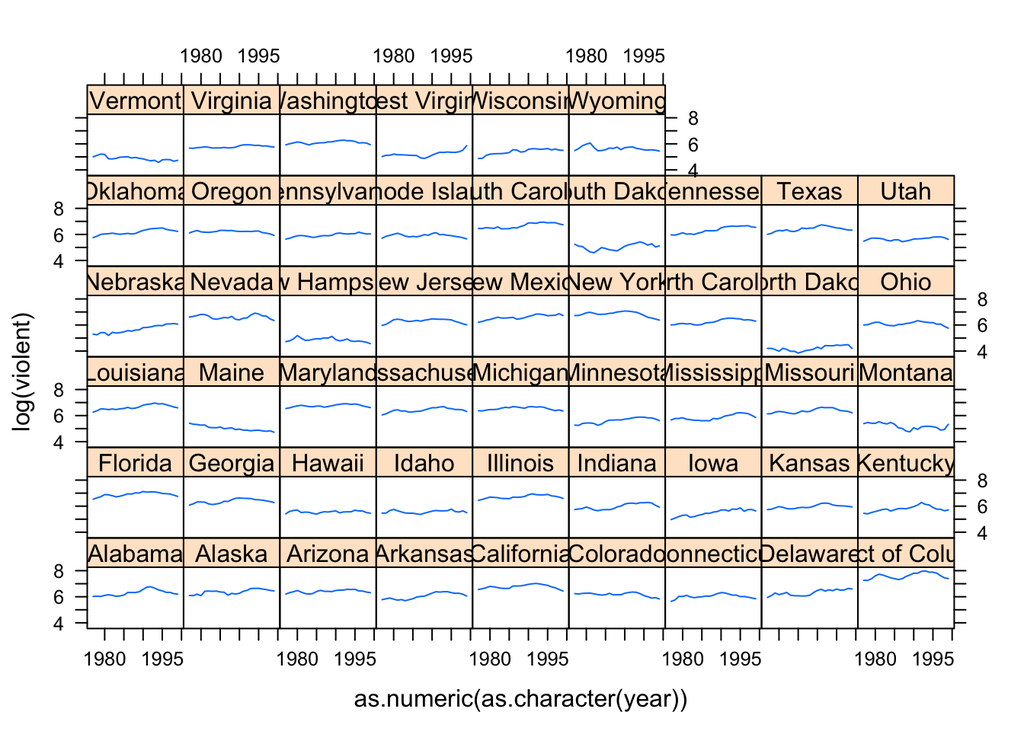

```r
library("lattice")
xyplot(log(violent) ~ as.numeric(as.character(year)) | state , data = Guns, type = "l")
```